# **Modelo inferencial: Regresión logística**

- Modelo utilizado en la inferencia para entender el rol de variables de entrada importantes al explicar una variable respuesta categórica $Y$.
- Se modela la probabilidad de que suceda el evento de interés, condicionado a un vector de variables explicativas $Pr(Y=1|X)$, dada por:

$$p(X)=\frac{e^{\beta_0+\beta_1X_1+...+\beta_pX_p}}{1+e^{\beta_0+\beta_1X_1+...+\beta_pX_p}}$$

- A partir de la cual llegamos a expresar:

$$\log\left(\frac{p(X)}{1-p(X)}\right)=\beta_0+\beta_1X_1+...+\beta_pX_p$$

- La regresión es estimada a partir de la maximización de la función del logaritmo de verosimilitud (cóncava), utilizando el algoritmo de Newton-Rhapson.

[figure not shown]

# **Optimización del modelo: Algoritmo genético**

- Se busca un modelo parsimonioso que envuelva un subconjunto de variables de entrada adecuado.
- *Primera idea:* selección exhaustiva.

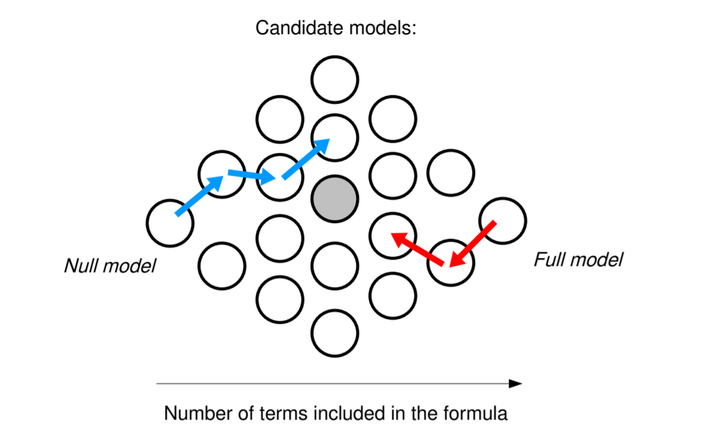

- El algoritmo genético explora solo un subconjunto de todos los posibles modelos, con sesgo hacia los mejores.
- Se codifican vectores de ceros y unos para indicar qué términos están presentes y cuáles no dentro de la regresión y se pasa por un proceso de *evolución adaptativa*.
- Se producen modelos de tres maneras: (1) reproducción asexual, (2) reproducción sexual e (3) inmigración.
- En cada generación se estimará modelos con su respectiva *aptitud*, denotada por $\omega$:

$$\omega_i=\exp(-(AIC_i-AIC_{mejor}))$$

- El algoritmo genético se detendrá cuando el AIC caiga bajo un umbral específico.

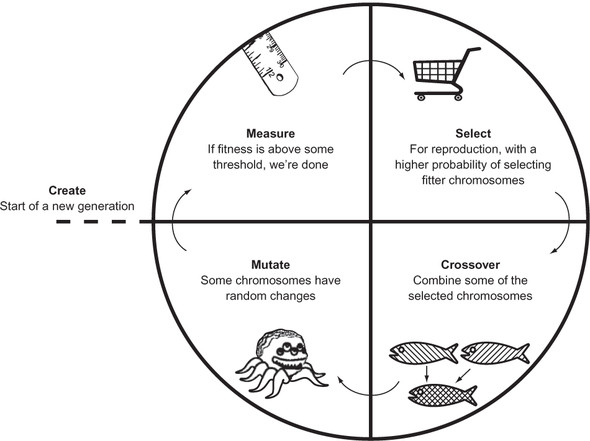